# Australia Fire Analysis

Group BH 2

11/5/2020

##### Introductory paragraph

Our domain is the Australian bushfires that occured at the beginning of 2020. We found a data set that compiled multiple sources ranging from NASA to the Australian Government and cleaned this data using a script. This dataset was fairly large, with 1500 rows and 30 columns of data. We downloaded the dataset from the tidy Tuesday dataset sourced from NASA and the New South Wales Rural Fire Service courtesy of Dean Marchiori. As a team, we felt particularly drawn to this dataset due to the large impact climate change is having on our world. We felt that we could ask meaningful questions of this dataset that pertain to climate change, such as what time of year do the most fires occur and why might that be? Where geographically do the fires occur and which populations are most impacted by this? How many lives and how much land is lost as a result of the fires, and how much flora/fauna is destroyed? As climate change gets worse, knowing the answers to these questions and being able to communicate the sheer extent to which fires are destroying lives becomes increasingly important in terms of being able to effect policy change and start a global conversation on the importance of preventative measures and harm reduction methods.

### Chart 1 Description

- The first chart we looked into is the Temperature and what the patterns look like over the time span we chose. By filtering the temperatures of Major Australian cities to find the mean per year we were able to create a chart with mean temperatures by year with the Major cities

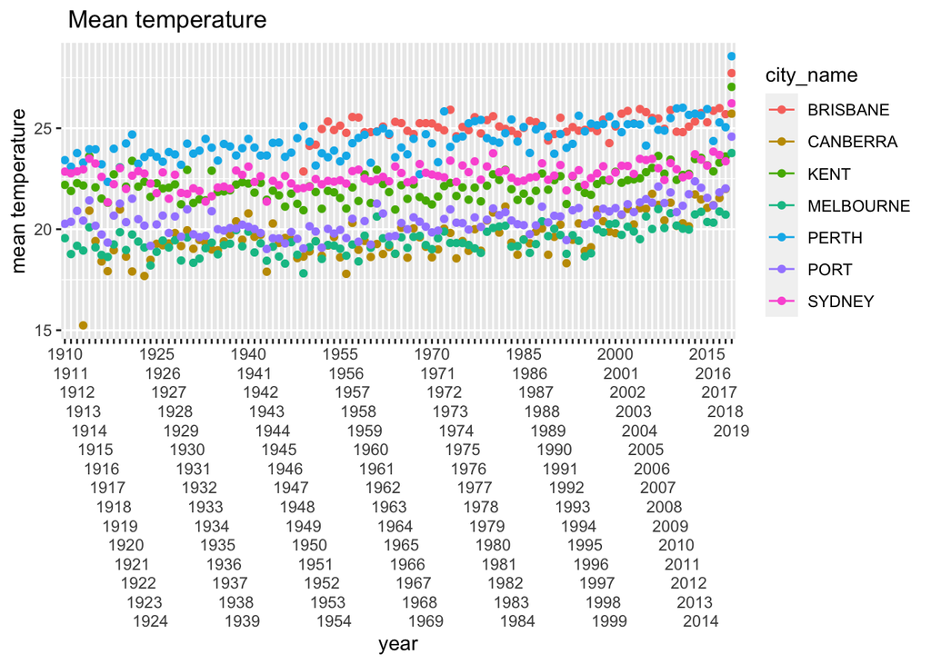

#### Notable Observations Chart 1

- Here we observe the mean temperature across the various major cities in Australia. Initially one can see the blue scatter for Perth start out and trend higher all the way towards the end in Temperature (Celcius). Perth is on the far Western portion of the country with higher temperatures. In addition to this we see Brisbane trending higher in temperature which is related to its positioning closer to the Equator compared to the other large Eastern Australian cities analyzed. Conversely we see Melbourne trending with some of the lowest temperatures with it geography furthest south on Australia furthest from the equator.

### Chart 2 Description

- This chart is meant to show the average brightness temperatures of the Australian fires in the beginning of 2020. This is important as it can later be compared to fires in the past. This comparison can lead to a conclusion about whether or not global warming and the brightness temperatuers of Australian wildfires are correlated.

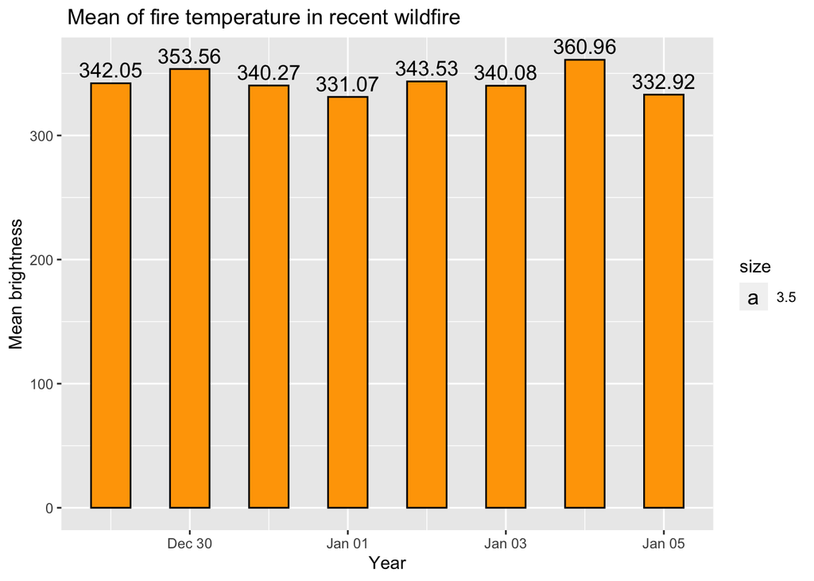

### Chart 3 Description

- In this chart we looked at the years 1850 to 2020 by taking the cities in the data set and taking the mean rainfall we were able to see summary statistics for various places in addition to grouping and seeing them as a whole. The plot shows the output from the group cities and their average rainfall grouped by year and city. It is evident that Sydney and the eastern cities have different rainfall then the western ones.

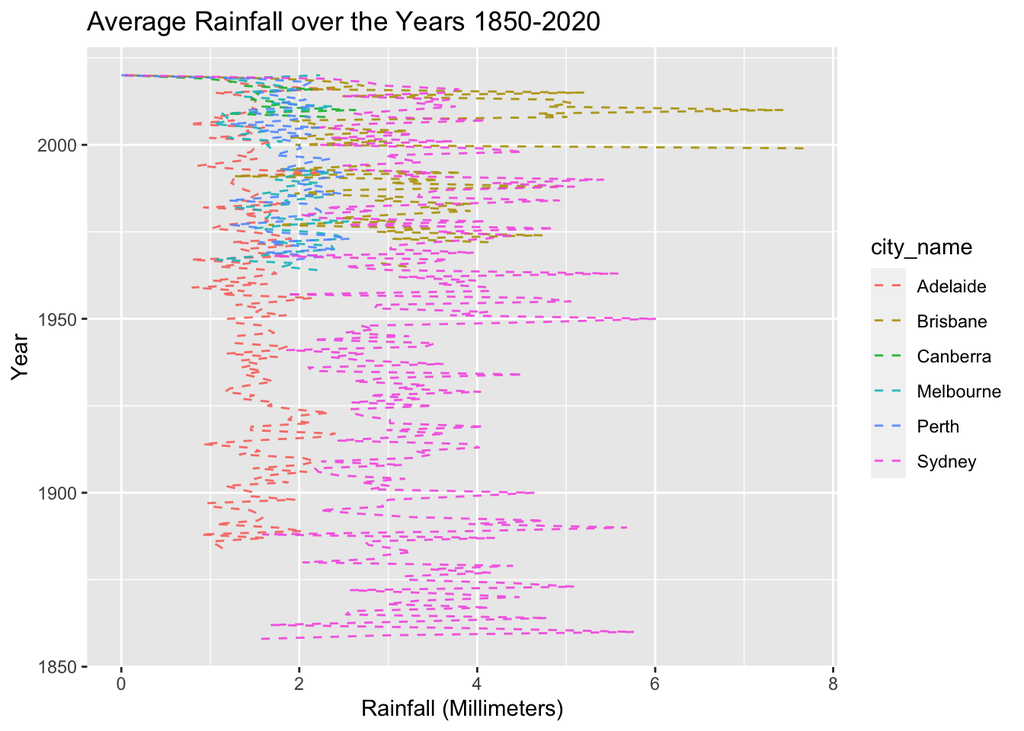